# Revenue optimization

Rob Trangucci & Jonah Gabry

January 9, 2017

## Problem set-up

The decision problem we want to solve is the following:

$$\begin{align*}
\arg\max_{p \in P} \mathbb{E}_q[q(p) \, p]
\end{align*}$$

Because we have complete control over price, the random variable contributing to the expectation is quantity. That’s what we’ll be modeling for these movies, the quantity as a function of price.

```r
movie_data <- readRDS('movie_data_tt.RDS')
head(movie_data)
```

```
##   units_sold                          title price       date release_year
## 1        248 The Shawshank Redemption(1994)     7 2015-01-11         1994
## 2        149 The Shawshank Redemption(1994)     7 2015-01-18         1994
## 3        335 The Shawshank Redemption(1994)     7 2015-01-25         1994
## 4         25 The Shawshank Redemption(1994)     7 2015-02-01         1994
## 5          0 The Shawshank Redemption(1994)     7 2015-02-08         1994
## 6        425 The Shawshank Redemption(1994)     7 2015-02-15         1994
##   rating
## 1    9.1
## 2    9.1
## 3    9.1
## 4    9.1
## 5    9.1
## 6    9.1
```

We’ve got the number of units sold per week, the date corresponding to the Sunday of every week end, the title, the price (in US dollars), the release year and the IMDB rating.

```r
N_titles <- length(unique(movie_data$title))
N_titles
```

```
## [1] 100
```

We’re working with 100 titles. We should first want to learn whether price is related to quantity for our movies.

We’ll start with a simple model and build it up slowly. First, we’ll define our likelihood to be the negative binomial probability mass function over the number of units sold, denoted below as $\texttt{qty_sld}$.

$$\begin{align*}
\texttt{qty_sld}_{m,t} & \sim \text{Neg-Binomial-log}(\eta_{m,t}, \phi) \\
\eta_{m,t} & = \alpha + \beta \, p_{m,t}
\end{align*}$$

The negative binomial mass function we’ll use is called $\texttt{neg_binomial_2_log}(\text{ints} \, y, \text{reals} \, \eta, \text{reals} \, \phi)$ in Stan. This is negative binomial mass function that is parameterized in terms of its log-mean, $\eta$, and its precision $\phi$. This means that $\mathbb{E}[y] \, = exp(\eta)$ and $\text{Var}[y] = \exp(\eta) + \exp(\eta)^2 / \phi$.

We can use this distribution for our outcome, qty_sld, because we have integer outcomes (number of movies sold per week). However, this isn’t a good enough reason to use the negative binomial distribution. We could use a Poisson distribution. However, the Poisson distribution has only one parameter, which requires that the mean of the Poisson random variable be equal to the variance of the random variable. However, our data appear to be overdispersed. We can check this by taking the mean of qty_sld for each movie and comparing it to the variance of qty_sld of each movie. We want to do this check because we would assume that if the data were generated by a Poisson distribution, each movie would have a variance roughly equal to its mean. We probably wouldn’t expect this to hold across movies because different movies likely have different average sales per week.

```r
movie_data %>% group_by(title) %>%
  summarise(mean_qty_sld = mean(units_sold),
            var_qty_sld = var(units_sold))
```

```
## # A tibble: 100 × 3
##                          title mean_qty_sld var_qty_sld
##                          <chr>        <dbl>       <dbl>
## 1           12 Angry Men(1957)        10.12    238.8833
## 2  2001: A Space Odyssey(1968)        52.46   6170.3759
## 3     A Clockwork Orange(1971)        14.08    455.7486
## 4                  Alien(1979)        40.32   2870.4669
## 5                 Aliens(1986)        57.48   6272.0506
## 6          All About Eve(1950)         9.98    312.1833
## 7                Amadeus(1984)        71.74   6371.4208
## 8        American Beauty(1999)       118.96  43740.4882
## 9     American History X(1998)       147.88  59895.0465
## 10        Apocalypse Now(1979)        31.28   3306.3282
## # ... with 90 more rows
```

So it does appear that the variance of the weekly sales data is greater than the mean, indicating that our outcome would be better modeled by a negative binomial distribution than by a Poisson distribution.

Let’s prep the data. First, because we’re concerned about comparing our predictions for certain products, and we’d like to do the comparison in Stan, we should convert our titles to integers.

```r
t <- max(table(movie_data$title))
J <- length(unique(movie_data$title))
movie_data <- movie_data %>%
  mutate(title_fac = as.factor(title),
         ttl_idx = as.integer(title_fac),
         ids = rep(1:t,J),
         wk_idx = lubridate::isoweek(date),
         mo_idx = lubridate::month(date))
```

We create the list to pass into RStan as data. We’ll be thorough and include everything we think we’ll use in a model.

```r
stan_dat_simple <- with(movie_data, list(qty_sld = units_sold,
                                         price = price,
                                         N = length(price),
                                         J = J,
                                         t = t,
                                         M = length(unique(mo_idx)),
                                         W = length(unique(wk_idx)),
                                         ttl_idx = ttl_idx,
                                         wk_idx = wk_idx,
                                         mo_idx = mo_idx))
```

Before we fit the first model we defined above, let’s generate some fake data against which to test our Stan program. If we are able to recover known parameter values, it is a good indication that our Stan program is working.

Let’s compile the fake data generating code in the file simple_NB_regression_dgp.stan.

```r
comp_dgp_simple <- stan_model('simple_NB_regression_dgp.stan')
```

We need to pass in values for $\texttt{alpha}$ and $\texttt{beta}$ and $\texttt{phi}$ so we can generate $\texttt{qty_sld}$ from the fake data model.

```r
fake_gen_data <- stan_dat_simple
fake_gen_data$price <- rnorm(fake_gen_data$N)
fake_gen_data$alpha <- 2
fake_gen_data$beta <- -0.2
fake_gen_data$phi <- 2
```

We’re going to generate one draw from the fake data model so we can use the data to fit our model and compare the known values of the parameters to the posterior density of the parameters.

```r
fitted_model_dgp <- sampling(comp_dgp_simple, data = fake_gen_data, chains = 1, cores = 1, iter = 1, algorithm='Fixed_param')
```

```
##
##
## Chain 1, Iteration: 1 / 1 [100%]  (Sampling)
##  Elapsed Time: 3e-06 seconds (Warm-up)
##                0.001664 seconds (Sampling)
##                0.001667 seconds (Total)
```

```r
samps_dgp <- rstan::extract(fitted_model_dgp)
```

We create a new dataset with the fake outcome data replacing the true observed outcomes.

```r
stan_dat_fake <- fake_gen_data
stan_dat_fake$qty_sld <- samps_dgp$y_gen[1,]
```

```r
comp_model_NB <- stan_model('simple_NB_regression.stan')
```

Now we run our NB regression over the fake data and extract the samples to examine posterior predictive checks and to check whether we’ve sufficiently recovered our known parameters, $\texttt{alpha}$ $\texttt{beta}$.

```r
fitted_model_NB <- sampling(comp_model_NB, data = stan_dat_fake, chains = 4, cores = 4)
samps_NB <- rstan::extract(fitted_model_NB)
samps_pars <- as.matrix(fitted_model_NB, pars = c('alpha','beta','phi'))
```

```r
print(fitted_model_NB,pars=c('alpha','beta','phi'))
```

```
## Inference for Stan model: simple_NB_regression.
## 4 chains, each with iter=2000; warmup=1000; thin=1;
## post-warmup draws per chain=1000, total post-warmup draws=4000.
##
##        mean se_mean   sd  2.5%   25%   50%   75% 97.5% n_eff Rhat
## alpha  2.02       0 0.01  1.99  2.01  2.02  2.02  2.04  4000    1
## beta  -0.19       0 0.01 -0.21 -0.20 -0.19 -0.18 -0.17  4000    1
## phi    1.97       0 0.05  1.87  1.93  1.97  2.00  2.07  4000    1
##
## Samples were drawn using NUTS(diag_e) at Fri Jan 27 18:13:55 2017.
## For each parameter, n_eff is a crude measure of effective sample size,
## and Rhat is the potential scale reduction factor on split chains (at
## convergence, Rhat=1).
```

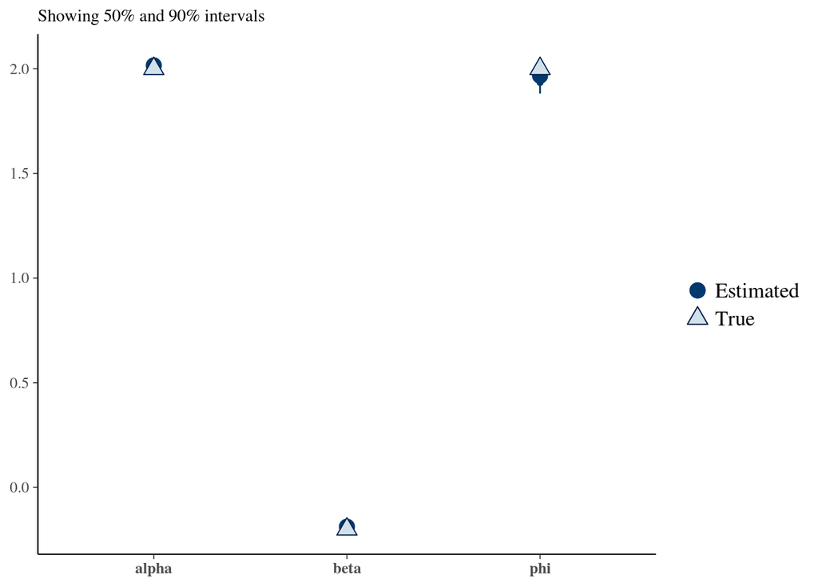

```r
bayesplot::mcmc_recover_intervals(samps_pars, c(2,-0.2, 2))
```

The parameter recovery looks good. Let’s run the model over the real data and see how our model fares!

```r
fitted_model_NB <- sampling(comp_model_NB, data = stan_dat_simple, chains = 4, cores = 4)
samps_NB <- rstan::extract(fitted_model_NB)
```

Let’s look at our predictions vs. the data.

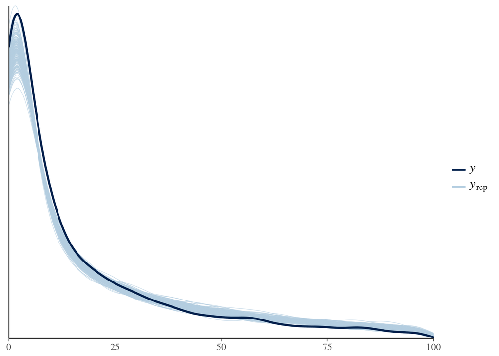

```r
bayesplot::ppc_dens_overlay(stan_dat_simple$qty_sld,
                            samps_NB$pp_y[1:200,]) + xlim(c(0,100))
```

It appears that our data generating process that we’ve encoded in our model doesn’t match the data we’ve been given. We’re over-estimating the tails of the data and under-estimating the small counts. Are there other statistics we can look at to determine what’s missing from the model?

We can look at the distribution of the means vs. our observed means by movie to see whether we’re at least modeling the means well at the movie level.

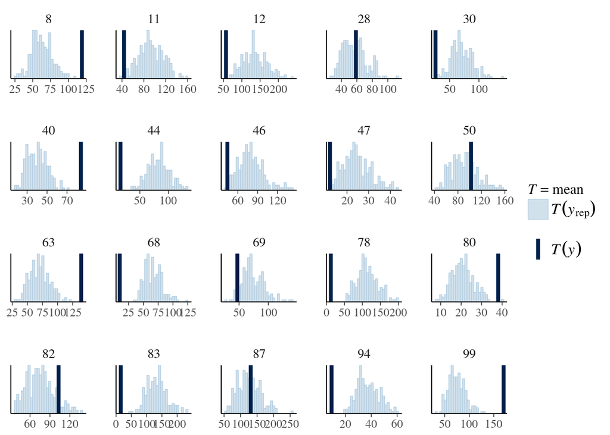

```r
random_20_groups <- with(stan_dat_simple, sample(1:J, 20))
sel_vec <- stan_dat_simple$ttl_idx %in% random_20_groups
bayesplot::ppc_stat_grouped(stan_dat_simple$qty_sld[sel_vec],
                            samps_NB$pp_y[1:200,sel_vec], group = stan_dat_simple$ttl_idx[sel_vec], stat = 'mean')
```

It appears that we aren’t modeling the means well for each movie. Let’s add a hierarchical intercept parameter, $\alpha_m$ at the movie level to our model.

$$\begin{align*}
\texttt{qty_sld}_{m,t} & \sim \text{Neg-Binomial-log}(\eta_{m,t}, \phi) \\
\eta_{m,t} & = \alpha_b + \beta \, p_{m,t} \\
\alpha_m & \sim \text{Normal}(\alpha, \sigma_{\alpha})
\end{align*}$$

In our stan model, $\alpha_m$ is the $m$-th element of the vector $\texttt{alpha}$ defined in the parameter vector.

```r
comp_model_NB_hier <- stan_model('hier_NB_regression.stan')
```

```r
fitted_model_NB_hier <- sampling(comp_model_NB_hier, data = stan_dat_simple, chains = 4, cores = 4)
```

Let’s examine the fit of the new model.

```r
print(fitted_model_NB_hier, pars = c('sigma_alpha','beta','alpha','phi','alphas'))
```

```
## Inference for Stan model: hier_NB_regression.
## 4 chains, each with iter=2000; warmup=1000; thin=1;
## post-warmup draws per chain=1000, total post-warmup draws=4000.
##
##              mean se_mean   sd  2.5%   25%   50%   75% 97.5% n_eff Rhat
## sigma_alpha  1.14    0.00 0.08  0.99  1.09  1.14  1.20  1.33  4000 1.00
## beta        -0.18    0.00 0.02 -0.24 -0.20 -0.18 -0.17 -0.13    94 1.02
## alpha        5.34    0.02 0.26  4.83  5.18  5.35  5.51  5.85   119 1.01
## phi          0.47    0.00 0.01  0.46  0.47  0.47  0.48  0.49  4000 1.00
## alphas[1]    4.17    0.02 0.32  3.53  3.96  4.17  4.37  4.80   165 1.01
## alphas[2]    5.17    0.02 0.26  4.67  5.00  5.17  5.34  5.69   229 1.01
## alphas[3]    5.14    0.03 0.39  4.35  4.88  5.14  5.39  5.94   128 1.01
## alphas[4]    5.41    0.02 0.31  4.80  5.20  5.41  5.60  6.03   163 1.01
## alphas[5]    5.78    0.02 0.32  5.16  5.57  5.77  5.98  6.39   163 1.01
## alphas[6]    4.14    0.03 0.32  3.51  3.92  4.14  4.36  4.77   165 1.01
## alphas[7]    5.39    0.02 0.25  4.91  5.22  5.39  5.55  5.90   257 1.01
## alphas[8]    6.54    0.03 0.31  5.93  6.32  6.54  6.74  7.15   150 1.01
## alphas[9]    6.26    0.02 0.27  5.76  6.08  6.26  6.44  6.79   215 1.01
## alphas[10]   5.56    0.03 0.35  4.86  5.34  5.55  5.78  6.27   135 1.01
## alphas[11]   5.24    0.02 0.28  4.69  5.05  5.24  5.43  5.80   183 1.01
## alphas[12]   5.17    0.02 0.26  4.68  5.00  5.17  5.34  5.70   249 1.01
## alphas[13]   5.99    0.02 0.30  5.39  5.79  5.99  6.19  6.59   160 1.01
## alphas[14]   3.77    0.02 0.31  3.17  3.56  3.77  3.98  4.38   172 1.01
## alphas[15]   5.03    0.02 0.30  4.43  4.82  5.03  5.23  5.63   168 1.01
## alphas[16]   4.85    0.03 0.35  4.16  4.62  4.85  5.08  5.54   143 1.01
## alphas[17]   6.09    0.02 0.26  5.59  5.91  6.08  6.25  6.62   198 1.01
## alphas[18]   3.83    0.01 0.25  3.36  3.67  3.82  3.99  4.33   330 1.00
## alphas[19]   2.42    0.03 0.34  1.75  2.20  2.41  2.65  3.10   169 1.01
## alphas[20]   3.82    0.02 0.28  3.28  3.63  3.81  4.00  4.39   253 1.01
## alphas[21]   4.84    0.02 0.27  4.33  4.67  4.83  5.00  5.38   224 1.01
## alphas[22]   6.49    0.02 0.29  5.94  6.29  6.48  6.68  7.06   184 1.01
## alphas[23]   6.66    0.02 0.26  6.15  6.49  6.66  6.83  7.18   234 1.01
## alphas[24]   6.66    0.03 0.36  5.97  6.42  6.66  6.88  7.40   132 1.01
## alphas[25]   6.18    0.02 0.29  5.64  5.99  6.18  6.37  6.77   178 1.01
## alphas[26]   5.60    0.04 0.42  4.74  5.33  5.61  5.88  6.46   122 1.01
## alphas[27]   6.38    0.02 0.26  5.89  6.21  6.37  6.54  6.91   249 1.00
## alphas[28]   5.89    0.03 0.32  5.25  5.68  5.89  6.10  6.54   160 1.01
## alphas[29]   6.75    0.03 0.33  6.11  6.53  6.75  6.97  7.43   147 1.01
## alphas[30]   4.98    0.02 0.31  4.37  4.78  4.97  5.18  5.63   164 1.01
## alphas[31]   7.08    0.02 0.26  6.57  6.90  7.07  7.25  7.63   202 1.01
```

[output cut: 59 more lines]

```
## alphas[91]   4.11    0.02 0.26  3.63  3.93  4.11  4.29  4.64   253 1.01
## alphas[92]   4.32    0.03 0.34  3.65  4.10  4.33  4.54  4.99   151 1.01
## alphas[93]   6.38    0.03 0.33  5.73  6.15  6.38  6.60  7.04   145 1.01
## alphas[94]   4.49    0.03 0.37  3.77  4.25  4.50  4.74  5.22   138 1.01
## alphas[95]   7.14    0.03 0.33  6.50  6.93  7.13  7.35  7.81   145 1.01
## alphas[96]   6.47    0.03 0.31  5.86  6.26  6.47  6.68  7.09   155 1.01
## alphas[97]   6.63    0.02 0.29  6.06  6.44  6.62  6.83  7.22   167 1.01
## alphas[98]   4.47    0.01 0.25  3.99  4.30  4.47  4.64  5.00   303 1.00
## alphas[99]   6.69    0.02 0.30  6.10  6.49  6.69  6.89  7.28   176 1.01
## alphas[100]  6.76    0.02 0.30  6.18  6.56  6.76  6.95  7.33   162 1.01
##
## Samples were drawn using NUTS(diag_e) at Fri Jan 27 18:19:40 2017.
## For each parameter, n_eff is a crude measure of effective sample size,
## and Rhat is the potential scale reduction factor on split chains (at
## convergence, Rhat=1).
```

The effective samples are quite low for many of the parameters. This indicates that there are problems with our parameterization of the model. We can reparameterize the random intercept $\alpha_m$, which is distributed:

$$\begin{align*}
\alpha_m & \sim \text{Normal}(\alpha, \sigma_{\alpha})
\end{align*}$$

Instead, we should use the non-centered parameterization for $\alpha_m$. We define a vector of auxiliary variables in the parameters block, $\texttt{alphas_raw}$ that is given a $\text{Normal}(0, 1)$ prior in the model block. We then make $\texttt{alphas}$ a transformed parameter:

$$\begin{verbatim}
transformed parameters {
vector[J] alphas;
alphas = alpha + sigma_alpha * alphas_raw;
}
\end{verbatim}$$

This gives $\texttt{alphas}$ a $\text{Normal}(\alpha, \sigma_\alpha)$ distribution, but it decouples the dependence of the density of each element of $\texttt{alphas}$ from $\texttt{sigma_alpha}$ ($\sigma_\alpha$). hier_NB_regression_ncp.stan uses the non-centered parameterization for $\texttt{alphas}$. We will examine the effective sample size of the fitted model to see whether we’ve fixed the problem with our reparameterization.

```r
comp_model_NB_hier_ncp <- stan_model('hier_NB_regression_ncp.stan')
```

[output not shown]

```r
fitted_model_NB_hier_ncp <- sampling(comp_model_NB_hier_ncp, data = stan_dat_simple, chains = 4, cores = 4)
```

Examining the fit of the new model

```r
print(fitted_model_NB_hier_ncp, pars = c('sigma_alpha','beta','alpha','phi','alphas'))
```

```
## Inference for Stan model: hier_NB_regression_ncp.
## 4 chains, each with iter=2000; warmup=1000; thin=1;
## post-warmup draws per chain=1000, total post-warmup draws=4000.
##
##              mean se_mean   sd  2.5%   25%   50%   75% 97.5% n_eff Rhat
## sigma_alpha  1.14    0.00 0.08  0.99  1.08  1.14  1.19  1.32   448 1.01
## beta        -0.18    0.00 0.02 -0.23 -0.20 -0.18 -0.17 -0.14   837 1.00
## alpha        5.35    0.01 0.26  4.82  5.19  5.36  5.52  5.85   647 1.01
## phi          0.47    0.00 0.01  0.46  0.47  0.47  0.48  0.49  4000 1.00
## alphas[1]    4.18    0.01 0.32  3.57  3.97  4.18  4.40  4.79  1382 1.00
## alphas[2]    5.18    0.01 0.26  4.67  5.01  5.18  5.36  5.68  1888 1.00
## alphas[3]    5.15    0.01 0.39  4.38  4.90  5.14  5.41  5.91  1077 1.00
## alphas[4]    5.41    0.01 0.30  4.84  5.20  5.41  5.61  6.01  1334 1.00
## alphas[5]    5.79    0.01 0.31  5.19  5.57  5.78  5.99  6.42  1441 1.00
## alphas[6]    4.15    0.01 0.32  3.51  3.93  4.16  4.37  4.80  1462 1.00
## alphas[7]    5.40    0.00 0.26  4.90  5.23  5.40  5.58  5.91  4000 1.00
## alphas[8]    6.55    0.01 0.31  5.94  6.35  6.55  6.75  7.16  1291 1.00
## alphas[9]    6.26    0.01 0.26  5.78  6.08  6.26  6.44  6.79  1776 1.00
## alphas[10]   5.58    0.01 0.35  4.91  5.34  5.58  5.81  6.26  1159 1.00
## alphas[11]   5.25    0.01 0.28  4.70  5.06  5.24  5.44  5.81  1654 1.00
## alphas[12]   5.18    0.00 0.25  4.69  5.01  5.18  5.35  5.67  4000 1.00
## alphas[13]   6.01    0.01 0.30  5.42  5.80  6.00  6.21  6.60  1431 1.00
## alphas[14]   3.78    0.01 0.32  3.18  3.57  3.78  3.99  4.41  1493 1.00
## alphas[15]   5.04    0.01 0.30  4.45  4.83  5.04  5.24  5.61  1383 1.00
## alphas[16]   4.86    0.01 0.34  4.19  4.64  4.86  5.09  5.54  1212 1.00
## alphas[17]   6.09    0.01 0.26  5.58  5.91  6.09  6.26  6.61  1814 1.00
## alphas[18]   3.84    0.00 0.25  3.36  3.67  3.83  4.00  4.35  4000 1.00
## alphas[19]   2.43    0.01 0.34  1.77  2.20  2.43  2.65  3.11  1424 1.00
## alphas[20]   3.82    0.00 0.27  3.30  3.64  3.82  4.00  4.37  4000 1.00
## alphas[21]   4.85    0.00 0.26  4.35  4.67  4.84  5.02  5.37  4000 1.00
## alphas[22]   6.49    0.01 0.28  5.96  6.29  6.49  6.69  7.07  1559 1.00
## alphas[23]   6.67    0.00 0.26  6.17  6.49  6.67  6.85  7.19  4000 1.00
## alphas[24]   6.68    0.01 0.35  5.97  6.43  6.68  6.91  7.37  1104 1.00
## alphas[25]   6.19    0.01 0.29  5.65  5.99  6.19  6.38  6.77  1544 1.00
## alphas[26]   5.62    0.01 0.43  4.79  5.33  5.62  5.91  6.47  1027 1.00
## alphas[27]   6.39    0.00 0.26  5.89  6.21  6.38  6.56  6.89  4000 1.00
## alphas[28]   5.91    0.01 0.32  5.28  5.69  5.91  6.12  6.54  1291 1.00
## alphas[29]   6.76    0.01 0.33  6.11  6.54  6.76  6.97  7.40  1237 1.00
## alphas[30]   4.99    0.01 0.31  4.39  4.79  4.99  5.20  5.59  1302 1.00
## alphas[31]   7.08    0.01 0.26  6.59  6.91  7.08  7.26  7.60  1639 1.00
```

[output cut: 59 more lines]

```
## alphas[91]   4.12    0.00 0.26  3.61  3.94  4.11  4.29  4.65  4000 1.00
## alphas[92]   4.34    0.01 0.33  3.67  4.12  4.34  4.56  4.99  1292 1.00
## alphas[93]   6.39    0.01 0.32  5.73  6.18  6.39  6.60  7.04  1243 1.00
## alphas[94]   4.51    0.01 0.36  3.80  4.27  4.51  4.76  5.22  1168 1.00
## alphas[95]   7.15    0.01 0.33  6.50  6.94  7.15  7.37  7.80  1188 1.00
## alphas[96]   6.48    0.01 0.32  5.87  6.26  6.48  6.70  7.10  1346 1.00
## alphas[97]   6.64    0.01 0.30  6.03  6.43  6.64  6.84  7.24  1496 1.00
## alphas[98]   4.49    0.00 0.26  4.01  4.32  4.48  4.66  5.00  4000 1.00
## alphas[99]   6.70    0.01 0.29  6.13  6.50  6.69  6.90  7.27  1399 1.00
## alphas[100]  6.77    0.01 0.30  6.19  6.57  6.77  6.97  7.36  1420 1.00
##
## Samples were drawn using NUTS(diag_e) at Fri Jan 27 18:26:23 2017.
## For each parameter, n_eff is a crude measure of effective sample size,
## and Rhat is the potential scale reduction factor on split chains (at
## convergence, Rhat=1).
```

This seems to have improved the effective sample sizes of $\texttt{alphas}$, though it has decreased the effective sample size of $\texttt{sigma_alpha}$. We’ll stick with the non-centered parameterization as long as it appears feasible when we examine our model diagnostics.

```r
samps_NB_hier_ncp <- rstan::extract(fitted_model_NB_hier_ncp, pars = c('pp_y'))
```

Extracting the draws from the model allows us to see how we’ve fitted the marginal distribution of the data with draws from the marginal posterior predictive distribution. That plot is below.

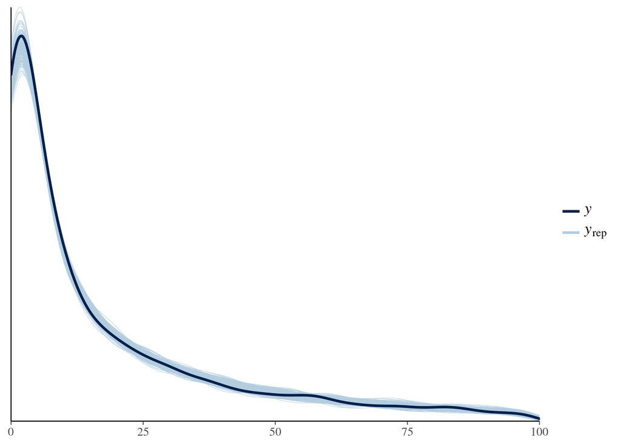

```r
bayesplot::ppc_dens_overlay(stan_dat_simple$qty_sld,
                          samps_NB_hier_ncp$pp_y[1:200,]) + xlim(c(0,100))
```

This looks quite nice. If we’ve captured the movie-level means well, then the posterior distribution of means by movie should match well with the observed means of the quantity of movie sales by week.

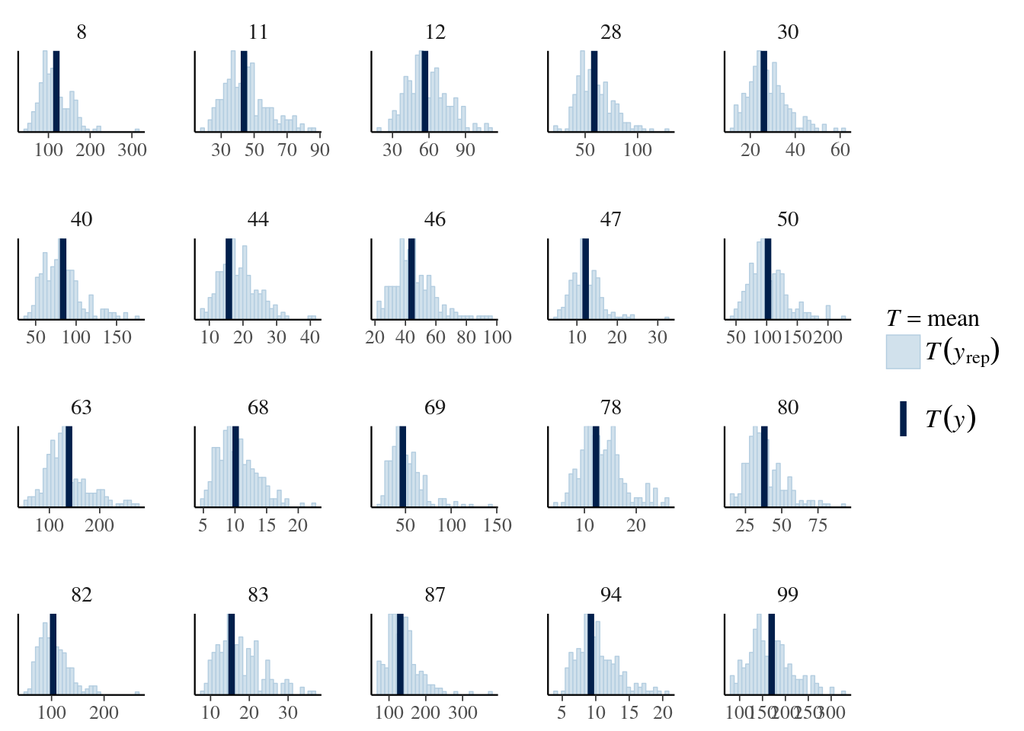

```r
bayesplot::ppc_stat_grouped(stan_dat_simple$qty_sld[sel_vec],
                            samps_NB_hier_ncp$pp_y[1:200,sel_vec], group = stan_dat_simple$ttl_idx[sel_vec], stat = 'mean')
```

Ok, so these plots look better. Perhaps if the level of movie sales differs by movie, the coefficient for price does too. We can add this to our model and observe the fit.

$$\begin{align*}
\text{qty_sld}_{m,t} & \sim \text{Neg-Binomial-log}(\eta_{m,t}, \phi) \\
\eta_{m,t} & = \alpha_m + \beta_m \, p_{m,t} \\
\alpha_m & \sim \text{Normal}(\alpha, \sigma_{\alpha}) \\
\beta_m & \sim \text{Normal}(\beta, \sigma_{\beta})
\end{align*}$$

```r
comp_model_NB_hier_slopes <- stan_model('hier_slopes_NB_regression_ncp.stan')
```

```r
fitted_model_NB_hier_slopes <- sampling(comp_model_NB_hier_slopes, data = stan_dat_simple, chains = 4, cores = 4)
samps_NB_hier_slopes <- rstan::extract(fitted_model_NB_hier_slopes, pars = c('sigma_beta',
                                                                              'pp_y'))
```

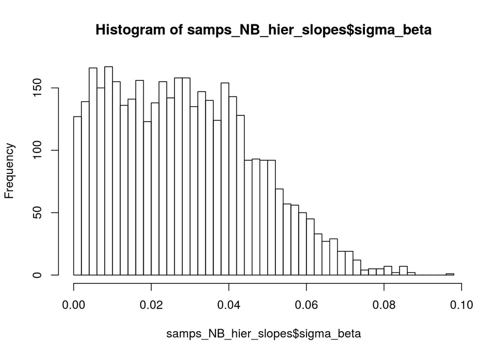

```r
hist(samps_NB_hier_slopes$sigma_beta,breaks=50)
```

While the model can’t specifically rule out zero from the posterior, it does have mass at small non-zero numbers, so we should leave in the hierarchy over $\texttt{betas}$. Plotting the marginal data density again, we can see the model still looks well calibrated.

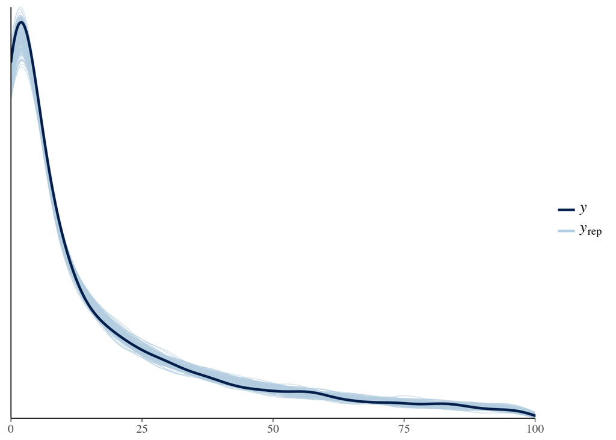

```r
bayesplot::ppc_dens_overlay(stan_dat_simple$qty_sld,
                            samps_NB_hier_slopes$pp_y[1:200,]) + xlim(c(0,100))
```

Perhaps we add monthly random intercepts to our model. Let’s look at the data to see if this is warranted.

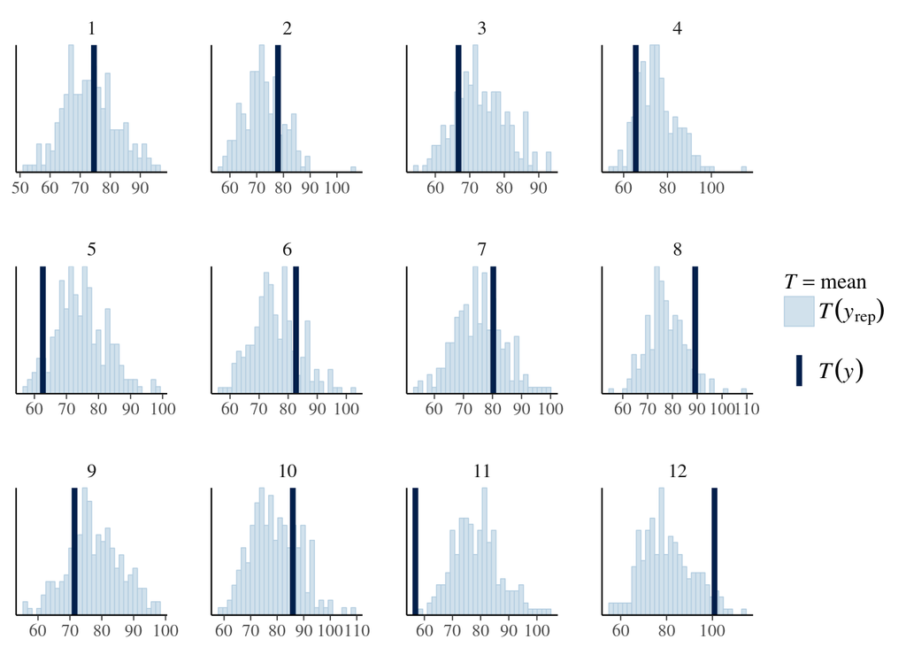

```r
bayesplot::ppc_stat_grouped(stan_dat_simple$qty_sld,
                            samps_NB_hier_slopes$pp_y[1:200,], group = stan_dat_simple$mo_idx, stat = 'mean')
```

We might be missing information in month indicators. It makes sense, when it gets colder out there might be more of an incentive to watch movies (at least in the Northeast).

```r
comp_model_NB_hier_mos <- stan_model('hier_slopes_NB_regression_mos.stan')
```

```r
fitted_model_NB_hier_mos <- sampling(comp_model_NB_hier_mos, data = stan_dat_simple, chains = 4, cores = 4)
```

We get divergent transitions in our run. Let’s reparameterize our prior on the $\texttt{mos}$ random intercept to be a centered hierarchical normal. We only observed divergent transitions after running the model with monthly random effect

```r
comp_model_NB_hier_mos_cp <- stan_model('hier_slopes_NB_regression_mos_cp.stan')
```

```r
fitted_model_NB_hier_mos_cp <- sampling(comp_model_NB_hier_mos_cp, data = stan_dat_simple, chains = 4, cores = 4, control = list(adapt_delta=0.99))
saveRDS(fitted_model_NB_hier_mos_cp,file = 'fitted_model_NB_hier_mos_cp.RDS')
samps_NB_hier_mos_cp <- rstan::extract(fitted_model_NB_hier_mos_cp, pars = c('pp_y'))
```

In the interest of brevity, we won’t go on expanding the model.

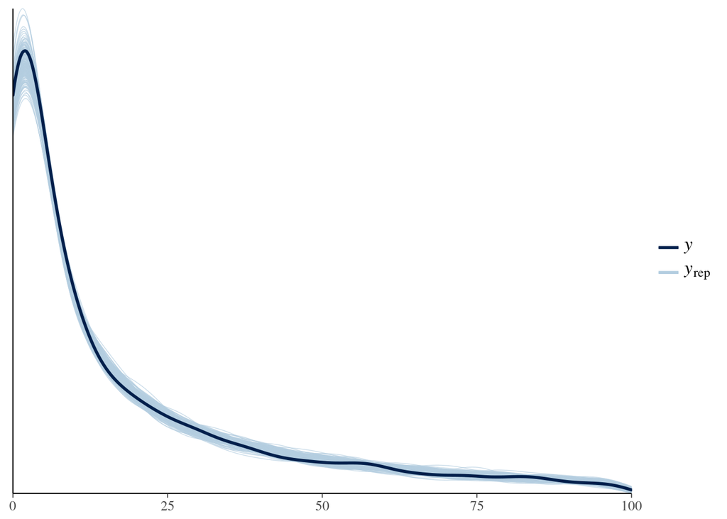

```r
bayesplot::ppc_dens_overlay(stan_dat_simple$qty_sld,
                            samps_NB_hier_mos_cp$pp_y[1:200,]) + xlim(c(0,100))
```

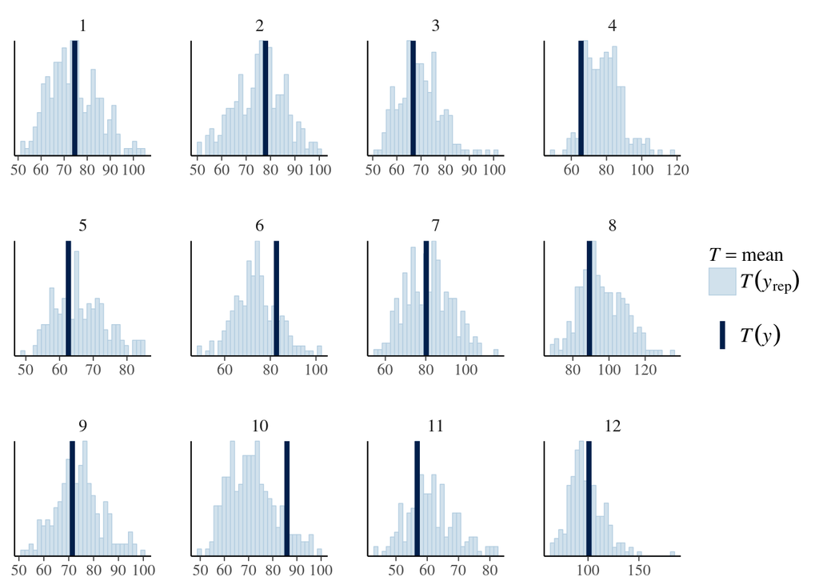

```r
bayesplot::ppc_stat_grouped(stan_dat_simple$qty_sld,
                            samps_NB_hier_mos_cp$pp_y[1:200,], group = stan_dat_simple$mo_idx, stat = 'mean')
```

As we can see, it appears that our monthly random intercept has captured a monthly pattern across all the movies.

## Revenue forecasts

Let’s modify the Stan program to generate revenue forecasts at different prices in the last week of data.

We want to predict quantity at each price, and then calculate revenue for each price.

```r
comp_rev <- stan_model('hier_slopes_NB_regression_mos_predict.stan')
```

```r
rev_model <- sampling(comp_rev, data = stan_dat_simple, chains = 4, cores = 4,
                      control = list(adapt_delta = 0.99))
samps_rev <- rstan::extract(rev_model)
```

Below we’ve generated our revenue curves for the first 10 products. These charts will give us precise quantification of our uncertainty around our revenue projections at any price for each product. This is immensely useful as a decision maker when choosing how to set prices for these products.

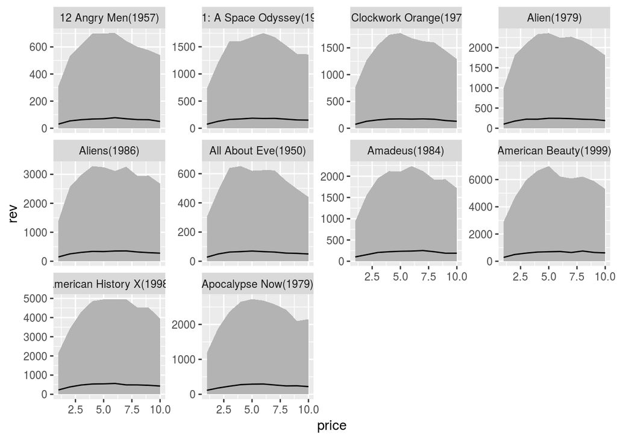

```r
movie_map <- unique(movie_data[,c('title','ttl_idx')])
median_rev <- apply(samps_rev$hypo_rev,c(2,3),median)
lower_rev <- apply(samps_rev$hypo_rev,c(2,3),quantile,0.05)
upper_rev <- apply(samps_rev$hypo_rev,c(2,3),quantile,0.95)
median_qty <- apply(samps_rev$hypo_qty_sld,c(2,3),median)
lower_qty <- apply(samps_rev$hypo_qty_sld,c(2,3),quantile,0.05)
upper_qty <- apply(samps_rev$hypo_qty_sld,c(2,3),quantile,0.95)
rev_df <- data.frame(rev = as.vector(t(median_rev)), lower = as.vector(t(lower_rev)),
                     upper = as.vector(t(upper_rev)),
                     price = rep(1:10,N_titles),
                     ttl_idx = as.vector(sapply(1:N_titles,rep,10)),
                     qty = as.vector(t(median_qty)),
                     lower_qty = as.vector(t(lower_qty)),
                     upper_qty = as.vector(t(upper_qty)))
rev_df <- rev_df %>% left_join(movie_map, by = 'ttl_idx')
sub_df <- rev_df %>% filter(ttl_idx <= 10)
ggplot(data = sub_df, aes(x = price, y = rev)) +
  geom_ribbon(aes(ymin = lower, ymax = upper), fill="grey70") + geom_line() +
  facet_wrap(~ title, scales = 'free_y')
```

Perhaps we’d also like to see the demand curves for each product. Below we’ve plotted the demand curves for the same products.

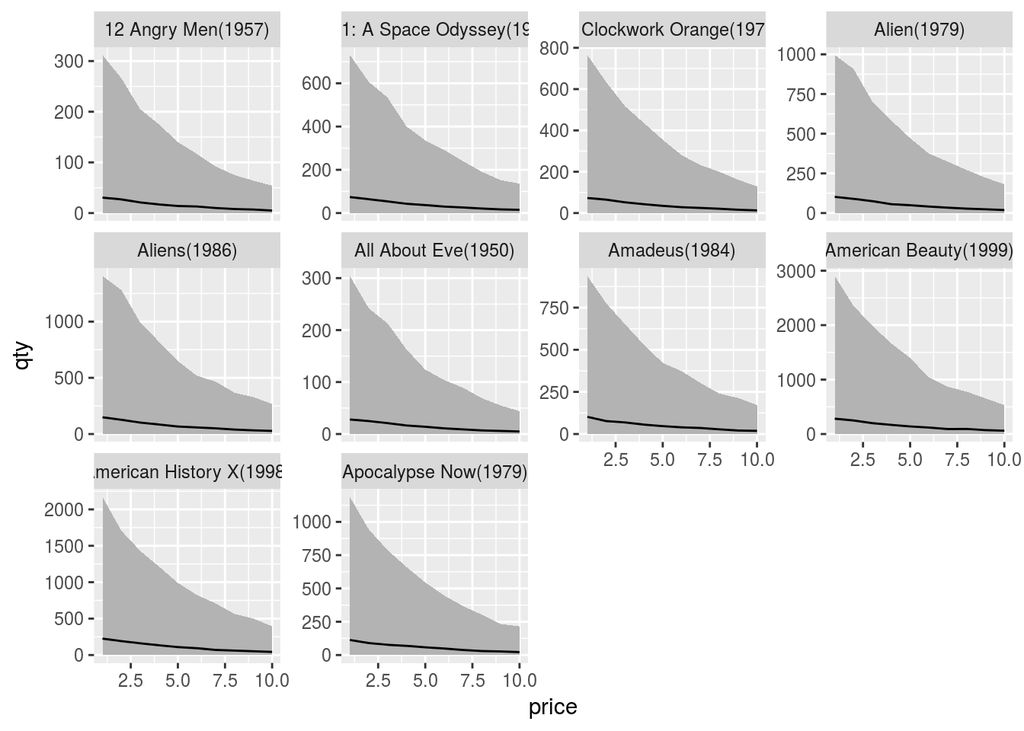

```r
ggplot(data = sub_df, aes(x = price, y = qty)) +
  geom_ribbon(aes(ymin = lower_qty, ymax = upper_qty), fill="grey70") + geom_line() +
  facet_wrap(~ title, scales = 'free_y')
```

Left as an exercise for the reader:

Let’s say our utility function is revenue. If we wanted to maximize expected revenue, we can take expectations at each price for each product, and choose the price that maximizes expected revenue. This will be called a maximum revenue strategy.

How can we generate the distribution of portfolio revenue (i.e. the sum of revenue across all the movies) under the maximum revenue strategy from the posterior draws of $\texttt{hypo_rev}$ we already have from $\texttt{samps_rev}$?

## Conclusion

We’ve walked through a full decision analysis problem with Stan. You should have a better sense how to build hierarchical generalized linear models in Stan, and then how to use the output to make decisions under uncertainty.